# Responses of ants to disturbance in Australia, with particular reference to functional groups - Hoffmann - 2003 - Austral Ecology - Wiley Online Library

[Austral Ecology](https://onlinelibrary.wiley.com/journal/14429993)

[Volume 28, Issue 4](https://onlinelibrary.wiley.com/toc/14429993/2003/28/4)

[figure not shown]

Full Access

# Responses of ants to disturbance in Australia, with particular reference to functional groups

[Benjamin D. Hoffmann](https://onlinelibrary.wiley.com/action/doSearch?ContribAuthorStored=Hoffmann%2C+Benjamin+D)

Corresponding author. Correspondence address.

[Alan N. Andersen](https://onlinelibrary.wiley.com/action/doSearch?ContribAuthorStored=Andersen%2C+Alan+N)

First published: 25 July 2003

https://doi.org/10.1046/j.1442-9993.2003.01301.x

Citations: 178

## Abstract

**Abstract** Ants are widely used as bioindicators in environmental assessment in Australia, partly because the responses of ant communities to disturbance are relatively well understood. In particular, the use of functional groups has provided a predictive framework for analysing ant community responses to disturbance in the absence of reliable information on the responses of individual species. Here we review 45 studies of the responses of Australian ant communities to disturbance, in order to: (i) identify individual species or species‐groups that respond consistently to disturbance; and (ii) examine the usefulness of the functional group scheme as a framework for predicting ant community responses under different disturbance regimes in different biogeographical regions. The most common forms of disturbance in our studies were fire (17 studies), mining (12; mostly studies of minesite restoration) and grazing (7), with other disturbances including clearing, logging, flooding, recreation, urbanization and farming. Responses of individual species were inevitably variable because of differences in vegetation type, severity of disturbance and time since disturbance. However, we identified a range of widespread species that showed predictable responses, including species of the *metallica* group of *Rhytidoponera* in temperate Australia (‘increasers’ in relation to disturbance), species of the *terebrans* and *denticulatus* groups of *Camponotus* (increasers), the *aeneovirens* group of *Melophorus* (increasers) from the arid zone, and *Iridomyrmex pallidus* (increaser) from the monsoonal region. The functional group scheme assessed here was not designed specifically in the context of disturbance, but nevertheless in some situations provides a useful framework for analysing ant community responses. Three distinct syndromes of functional group responses can be recognized. First, Dominant Dolichoderinae and Hot Climate Specialists are groups that prefer open environments, and tend to be favoured by low levels of disturbance in well‐forested habitats. Second, Opportunists and often also Generalized Myrmicinae are broadly adapted taxa with wide habitat tolerances, but are particularly sensitive to competitive interactions such that their responses oppose those of Dominant Dolichoderinae. Finally, Cryptic Species and Specialist Predators have highly specialized requirements that make them especially sensitive to disturbance. Functional groups are of most use in situations where disturbance causes substantial change in habitat structure, particularly in the ground‐layer. Functional groups are of least use in very open habitats, where disturbance merely increases what is already extensive bare ground, and has relatively little impact on microclimate. The ant functional group scheme can play an important role in assessing disturbance in mesic Australia, but may be of more limited use for this in the arid zone.

## Introduction

Of all terrestrial invertebrates, ants are the most widely used bioindicators in Australia. This is partly because of the great abundance, diversity and functional importance of ants in Australian environments, combined with their relative ease of sampling (Majer 1983; Greenslade & Greenslade 1984; Andersen 1990). However, it is also because an understanding of a taxon's responses to environmental stress and disturbance is fundamental to its effective use as a bioindicator (Andersen 1999), and such an understanding is better developed for ants than for any other invertebrate group.

An understanding of ant community dynamics in Australia is supported by a functional group scheme that classifies taxa at genus and species‐group levels according to their continental‐scale responses to environmental stress and disturbance (Andersen 1995; Table 1). The scheme is designed for analyses of ant community dynamics at biogeographical scales (Andersen 1997a), but has also provided a useful framework for predicting the responses of ant communities to disturbance at particular sites (Vanderwoude *et al*. 1997; King *et al*. 1998; Bisevac & Majer 1999). For example, disturbance in forested habitats of eastern and southern Australia typically leads to an increased abundance of Opportunists, particularly species of *Rhytidoponera* (Andersen 1990). The predictive capacity provided by such functional groups can play an important role in the use of ants as bioindicators (Andersen 1997b), helping to distinguish meaningful ‘signals’ from background ‘noise’, given the limited replication characteristic of most land‐use studies (Andersen 1999).

Table 1. Summary of functional groups of Australian ants, based on continental‐scale responses to environmental stress and disturbance (after Andersen 1997c)

| Group and major taxa | Characteristics |
| --- | --- |
| Dominant Dolichoderinae *Iridomyrmex*, *Anonychomyrma* | Abundant, highly active and aggressive species that favour hot and open habitats, and exert a strong competitive influence on other ants. |
| Subordinate Camponotini *Camponotus*, *Polyrhachis*, *Opisthopsis* | Co‐occurring with, and behaviourally submissive to, Dominant Dolichoderinae. Large body size, and often nocturnal foraging. |
| Hot Climate Specialists *Melophorus*, *Meranoplus*, *Monomorium* (part) | Arid‐adapted taxa with morphological, physiological or behavioural specializations that reduce their interaction with Dominant Dolichoderinae. |
| Cold Climate Specialists *Prolasius*, *Notoncus*, *Monomorium* (part) | Distribution centred on the cool‐temperate zone. Most abundant in habitats where Dominant Dolichoderinae are generally not abundant. |
| Tropical Climate Specialists *Oecophylla*, *Tetraponera*, many other tropical taxa | Distribution centred on the humid tropics. Occur in habitats where Dominant Dolichoderinae are generally not abundant. |
| Cryptic Species *Solenopsis*, *Hypoponera*, many other small ponerines and myrmicines | Forage predominantly within soil and litter, having relatively little interaction with epigaeic ants. |
| Opportunists *Rhytidoponera*, *Paratrechina*, *Aphaenogaster*, *Tetramorium* | Unspecialized, ‘weedy’ species characteristic of disturbed sites, or other habitats supporting low ant diversity. |
| Generalized Myrmicinae *Pheidole*, *Monomorium* (part), *Crematogaster* | Cosmopolitan genera occurring in most habitats. Rapid recruitment to, and successful defence of, clumped food resources. |
| Specialist Predators *Myrmecia*, *Cerapachys*, large ponerines | Relatively little interaction with other ants due to specialist diet, large body size, and small colony size. |

There are now more than 50 studies documenting the responses of Australian ant communities to disturbance, and it is timely that these responses be reviewed. In particular, the utility of the functional group scheme as a framework for predicting responses to disturbance at particular sites requires critical examination. The functional group scheme has been successfully applied in a disturbance context in forested habitats of higher rainfall regions, but recent studies suggest that it might be less useful in the arid zone (Hoffmann *et al*. 2000; Read & Andersen 2000). In addition, there are now sufficient studies to examine the extent to which individual species and species‐groups show consistent responses to disturbance.

Here, we provide a comprehensive review of the responses of Australian ants to disturbance. It needs to be noted that in most cases ‘disturbance’ does not refer to the actual removal of ant biomass (*sensu*Grime 1979), but to disturbance of the habitat in which ants occur. Habitat disturbance often has little direct impact on ants, especially those nesting in soil (Hölldobler & Wilson 1990), but acts indirectly through effects on vegetation structure, food supplies and competitive interactions (Andersen 1995). We specifically address two questions. First, can individual species or species‐groups be identified that respond consistently to habitat disturbance? Second, how useful is the functional group scheme as a framework for predicting ant community responses under different disturbance regimes in different biogeographical regions?

## Methods

### The data

We analysed all the studies we were aware of where quantitative data are provided on the responses of Australian ant communities to disturbance (*n* = 45; Fig. 1, Table 2), or where the responses of key species were described qualitatively without providing data (e.g. Neumann 1991, 1992). We sought to be comprehensive rather than selective in our inclusion of studies. This necessarily meant that the data we were dealing with were of highly variable quality. However, data quality was an explicit factor in our assessments of responses, and our aim was to seek recurring patterns of responses over a range of studies, so that our conclusions could not be determined by isolated spurious results. Our inclusive approach maximized the number of studies available for analysis, and avoided arbitrary judgements on what constituted a well‐designed study.

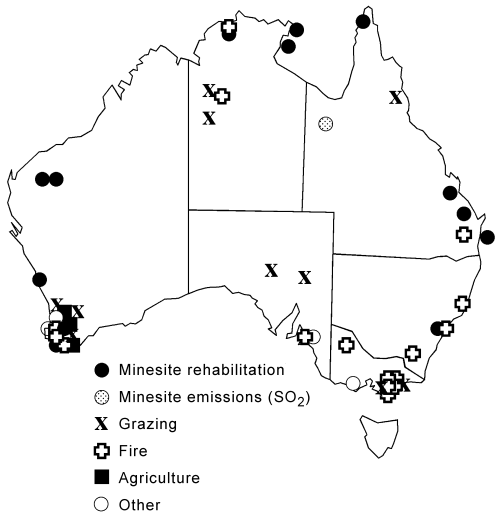

**Figure 1**

Open in figure viewer[PowerPoint](https://onlinelibrary.wiley.com/action/downloadFigures?id=f1&doi=10.1046%2Fj.1442-9993.2003.01301.x)

Location of experimental sites within studies investigating the responses of ants to disturbance used in this review. Symbols indicate the disturbance type under investigation. Some symbols may be obscured from view by others.

Table 2. Summary list of quantitative studies using ants as environmental indicators in Australia used in this review

| Disturbance type | Vegetation | Location | Collecting methods | Source |  |
| --- | --- | --- | --- | --- | --- |
| Fire/mining/farming | Jarrah forest | Dwellingup, WA | Pitfall traps at 4 sites | Majer (1978) |  |
| Fire | Wandoo woodland and jarrah forest | Kojonup, WA | Pitfall traps, soil and litter samples at 5 sites | Majer (1980) |  |
| Fire | Jarrah –*Banksia* woodland | 25 km south of Perth, WA | Pitfall traps at 6 sites | Whelan *et al*. (1980) |  |
| Fire | *Eucalyptus regnans* forest | Brindabella Range, ACT | Pitfall traps at 2 sites | O'Dowd and Gill (1984) |  |
| Fire | Semiarid heath and mallee | Wyperfeld National Park, Vic. | Pitfall traps at 2 sites | Andersen and Yen (1985) |  |
| Fire | Dry eucalypt forest | Belair National Park, SA | Pitfall traps at 2 sites | O'Dowd (1985) |  |
| Fire | Cool‐temperate heath and woodland | Wilson's Promontory, Vic. | Pitfall traps and baits at 2 sites | Andersen (1988) |  |
| Fire | Tropical savanna | Kakadu National Park, NT | Pitfall traps at 6 sites | Andersen (1991a) |  |
| Fire | *Eucalyptus regnans* forest | Victorian Central Highlands | Pitfall traps at 3 sites | Neumann (1991) |  |
| Fire/logging | *Eucalyptus regnans* forest | Victorian Central Highlands | Pitfall traps at 3 sites | Neumann (1992) |  |
| Fire/logging | *Eucalyptus regnans* forest | Victorian Central Highlands | Pitfall traps at 3 sites | Hosking and Turner (1997) |  |
| Fire | Wet sclerophyll forest | Dandenong Ranges, Vic. | Pitfall traps at 20 sites | Neville *et al*. (1997) |  |
| Fire | Dry eucalypt forest | Bauple State Forest nr. Gympie, Qld | Pitfall traps at 6 sites | Vanderwoude *et al*. (1997) |  |
| Fire | Eucalypt forest | Bulls Ground State Forest, NSW | Pitfall traps and litter samples at 12 sites | York (2000) |  |
| Fire | Semiarid woodland and Mitchell grassland | Victoria River District, NT | pitfall traps at 40 sites | Hoffmann (2003) |  |
| Fire/clearing and grazing | Cool‐temperate woodland | Rotamah Island, Vic. | Pitfall traps at 3 sites | Andersen and McKaige (1987) |  |
| Fire/clearing and mining | Dry sclerophyll forest | Tomago, near Newcastle, NSW | Pitfall traps at 44 sites | Jackson and Fox (1996) |  |
| Grazing | Dry eucalypt woodland | Kellerberin region, WA | Pitfall traps at 22 sites | Scougall *et al*. (1993) |  |
| Grazing/weed invasion | Gimlet woodland | Kellerberin region, WA | Pitfall traps at 26 sites | Abensberg‐Traun *et al*. (1996) |  |
| Grazing | Dry eucalypt woodland | 200 km NE Melbourne, Vic. | Pitfall traps at 15 sites | Bromham *et al*. (1999) |  |
| Grazing | Semiarid woodland and Mitchell grassland | Victoria River District, NT | Pitfall traps at 11 sites | Hoffmann (2000) |  |
| Grazing | Chenopod shrubland, mulga | Kingoonya region, SA | Pitfall traps at 40 sites | Hoffmann (2001) |  |
| Grazing | Arid chenopod shrubland and *Acacia* | Olympic Dam, SA | Pitfall traps at 42 sites | Read and Andersen (2000) |  |
| Clearing and grazing/clearing and rehabilitation | Tropical rainforest | Atherton Tableland, Qld | Pitfall traps, litter samples and baits at 3 sites | King *et al*. (1998) |  |
| Mine site rehabilitation | Heath | Eneabba, WA | Pitfall traps and hand collections at 16 sites | Majer *et al*. (1982) |  |
| Mine site rehabilitation | Monsoonal savannas | northern Australia | Pitfall traps at 22 sites | Majer (1984) |  |
| Mine site rehabilitation | Arid hummock grassland | Pilbara, WA | Pitfall traps at 5 sites | Dunlop and Majer (1985) |  |
| Mine site rehabilitation | Open forest on sand dunes | North Stradbroke Island, Qld | Pitfall traps, foliage beats, hand collections and litter samples at 15 sites | Majer (1985b) |  |
| Mine site rehabilitation | Tropical savanna | Ranger Uranium mine, NT | Pitfall traps at 8 sites | Andersen (1993) |  |
| Mine site rehabilitation | Jarrah forest | Dwellingup, WA | Pitfall traps at 15 sites | Majer and Nichols (1998) |  |
| Mine site rehabilitation | Subtropic woodland | German Creek, Qld | Pitfall traps at 10 sites | Andersen and Hoffmann (1999) |  |
| Mine site rehabilitation | Heath | Eneabba, WA | Pitfall traps at 10 sites | Bisevac and Majer (1999) |  |
| Mine site rehabilitation | Subtropic woodland | Callide mine nr Bioloea, Qld | Pitfall traps at 9 sites | Andersen *et al*. (2003) |  |
| Borrow pit rehabilitation | Arid hummock grassland, mulga and mixed *Acacia* | Pilbara, WA | Pitfall traps at 11 sites | Fletcher (1990) |  |
| Post flooding rehabilitation | Jarrah forest | Canning Reservoir, Perth, WA | Ppitfall traps at 10 sites | Woodroff and Majer (1981) |  |
| Revegetation, recreation | Open forest and woodland | Mount Lofty Ranges, SA | Pitfall traps at 19 sites | Yeatman and Greenslade (1980) |  |
| SO<sub>2</sub> emissions | Semiarid woodland | Mount Isa, Qld | Pitfall traps at 40 sites | Hoffmann *et al*. (2000) |  |
| SO<sub>2</sub> emissions | Semiarid woodland | Mount Isa, Qld | Pitfall traps at 40 sites | Andersen *et al*. (2002) |  |
| Urbanization | Urban gardens & coastal heath | Swan Coastal Plain, Perth, WA | Pitzall traps and hand collections at 45 sites (including 12 sites in Rossbach & Majer 1983) | Majer and Brown (1986) |  |
| Urbanization/plantations/grazing and weed invasion | Various woodlands, heath and dune vegetation | Yanchep National Park, WA | Pitfall traps at 20 sites | Burbidge *et al*. (1992) |  |
| Agriculture | Wandoo woodland | Dryandra State Forest, WA | Nest densities at 1 site (compared with Majer 1985a) | Majer *et al*. (1987) |  |
| Agriculture | Various heath and woodland | Wubin – Perenjori, WA | Comprehensive sampling at 6 sites | Keals and Majer (1991) |  |
| Agriculture | Heath and wandoo woodland | Durokoppin Reserve near Kellerberin, WA | Pitfall traps and hand collections at 22 sites | Lobry de Bruyn (1993) |  |
| Plantation | Wandoo woodland, mallee | Dryandra State Forest, WA | Pitfall traps at 14 sites | Majer (1985a) |  |
| Shrub invasion | Coastal health | Portland, Vic. | Pitfall traps at 6 sites | Clay & Schneider (2000) |  |

- NSW, New South Wales; NT, Northern Territory; Qld, Queensland; SA, South Australia; Vic., Victoria; WA, Western Australia.

The most common forms of disturbance in our 45 studies were fire (17 studies), mining (12; mostly studies of minesite restoration, including the borrow pit study of Fletcher (1990)) and grazing (7), with other disturbances including clearing, logging, flooding, recreation, urbanization, shrub invasion and farming. There is a concentration of studies (17) in Western Australia, which reflects the long history of work there by J. D. Majer and colleagues. The other studies were distributed as follows: Victoria (9), Queensland (7), Northern Territory (5), South Australia (4), New South Wales (2) and the Australian Capital Territory (1). No studies were from Tasmania.

Where the same data were presented in multiple papers, only the paper containing the most comprehensive or revised data was used. Where multiple sampling techniques were employed, only the data from pitfall traps were considered, in order to maximize comparability given that virtually all studies used pitfall traps. In some cases we pooled data from two or more similar sites to simplify the analyses into disturbed versus undisturbed. These were: (i) all sites in the two background (control) zones in Hoffmann *et al*. (2000); (ii) the many control and disturbed sites in Dunlop and Majer (1985), Fletcher (1990) and Lobry de Bruyn (1993); and (iii) the controls and 4‐ and 8‐year‐old rehabilitation sites in Andersen (1993).

Counts of ant species abundances are often transformed in order to reduce distortions caused by large numbers of ants falling into a few traps when traps are placed beside colony entrances or along foraging trails (Andersen 1990). A lack of transformation can seriously compromise the reliability of comparative studies. When raw data had not been scaled at the trap level, ant abundances were recalculated using ln(*x* + 1) transformations at the site level. Although scaling at the trap level is preferable, trap‐level data were generally unavailable.

The functional group scheme is a relatively new one, and has undergone substantial evolution over the past 10 years. For example, Greenslade's (1978) original group ‘Large Solitary Foragers’ was renamed ‘Specialist Predators’ by Andersen (1990), and expanded to include genera such as *Cerapachys*, *Colobostruma* and *Epopostruma*. Similarly, ‘Sub‐cryptic Species’ was proposed as a new group (Andersen & McKaige 1987) but then withdrawn (Andersen 1995). Some taxa have been reclassified as more information on them has become available; for example, species of *Tapinoma*, *Doleromyrma*, *Ochetellus* and the *turneri* group of *Odontomachus* are now regarded as Opportunists. Where possible, whenever a study used an older functional group classification, this was updated (see Andersen 1997c; Brown 2000) and data recalculated accordingly. Climate Specialists within Majer and Brown (1986), Keals and Majer (1991), Scougall *et al*. (1993) and Cryptic Species within Majer and Brown (1986) and Scougall *et al*. (1993) were excluded as they contained species from multiple groups and we were unable to separate them.

When assessing the responses of individual species, we used their absolute abundances. However, when assessing responses of functional groups we considered relative abundance (percentage of total ant abundance), because this is how functional groups are typically analysed. This means that a functional group response will not simply reflect the individual responses of component taxa, as it is also affected by the responses of other taxa. For studies that only report the absolute abundances of species, we recalculated the data as relative abundance for functional group analysis. The relative abundances of functional groups were also calculated from some studies that did not report them (e.g. Majer 1978; Fletcher 1990).

### Assessing responses to disturbance

Most of the studies report responses in the absence of formal statistical tests, and indeed the unreplicated nature of many studies was such that formal significance testing was inappropriate. Our assessments of the responses of taxa in any particular study are therefore necessarily qualitative. For each study, we assessed the responses of species and functional groups to disturbance according to a three point scale: 1, weak apparent response that very possibly represents background noise; 2, apparently clear and strong response; and 3, very strong response. We considered sample size and replication when assessing responses. For example, in both Andersen and Yen (1985) and Majer *et al*. (1982), Hot Climate Specialists showed an approximate halving of relative abundance with disturbance, but was scored 2 where there were only two sites (Andersen & Yen 1985) and scored 3 where there were 16 sites (Majer *et al*. 1982). We accept that our scoring involved considerable subjectivity, which is not ideal in meta‐analysis (Gates 2002), but we believe such an approach is unavoidable if the full range of studies is to be included. We use the terms ‘increaser’ and ‘decreaser’ to describe taxa whose abundances increase and decrease, respectively, with increasing levels of disturbance. Most species within any study did not show an apparent response, largely because there were insufficient data on them.

## Results

### Species responses

| Ant variable | Response | Source |
| --- | --- | --- |
| Subfamily Myrmeciinae |  |  |
| *Myrmecia* | – | Majer (1984) |
|  | ––– | Majer and Brown (1986) |
|  | –– | Lobry de Bruyn (1993) |
|  | + | Neville *et al*. (1997) |
| *Myrmecia forficata* | + + | Andersen (1988) |
| *Myrmecia pilosula* | + + | Andersen (1988) |
|  | – | Clay & Schneider (2000) |
| Subfamily Ponerinae |  |  |
| *Anochetus* | *–*– | Lobry de Bruyn (1993) |
| *Bothroponera ?oculata* | *–* | Vanderwoude *et al*. (1997) |
| *Bothroponera regularis* | *–*– | Lobry de Bruyn (1993) |
| *Brachyponera lutea* | + | Majer (1984) |
|  | – | Majer (1985b) |
|  | + + | Jackson and Fox (1996) |
|  | + | Vanderwoude *et al*. (1997) |
|  | + | Andersen and Hoffmann (1999) |
|  | + + | York (2000) |
|  | – | Read and Andersen (2000) |
| *Heteroponera ?imbellis* | *–*– | Vanderwoude *et al*. (1997) |
|  | –– | Clay & Schneider (2000) |
| *Hypoponera* | *–* | York (2000) |
| *Leptogenys adlerzi* | *–*– | Hoffmann (2000) |
| *Leptogenys* | + | York (2000) |
| *Mesoponera australis* | *–* | Vanderwoude *et al*. (1997) |
| *Odontomachus ruficeps* gp. | –– | Majer *et al*. (1982) |
|  | –– | Lobry de Bruyn (1993) |
| *Rhytidoponera* | *–*/+ | Bromham *et al*. (1999) |
| *Rhytidoponera aurata* | + + | Andersen (1991a) |
| *Rhytidoponera confusa* | + + | Andersen & McKaige (1987) |

[output cut: 455 more lines]

### Responses of species‐groups and genera

*Rhytidoponera inornata*, *R. tasmaniensis* and *R. trachypyx* are all members of the widespread *metallica* group, whose species are widely regarded as increasers (Andersen 1990). There were collectively 21 records of species from this group, with 14 of these increasing. Interestingly, all eight records from higher rainfall areas of south‐eastern Australia (the first three and fifth records of unspecified species from the group, plus the four records of *R. tasmaniensis*; Table 3) were increasing, with six of these strongly so. Species of other groups of *Rhytidoponera* showed mixed responses. There were nine records of species from the *convexa* group (including *R. violacea* and *R. rufithorax*), with six increasers and three decreasers. There were single records of individual species of the tropical *tenuis*, *reticulata, turneri*, *aurata* and *confusa* groups; the first three (all small‐ to medium‐sized species of open habitats; Andersen 2000a) were all strong decreasers, whereas the last two were strong increasers. Considering all the 42 records of *Rhytidoponera* species, there were 28 (67%) increasers (14 strongly so), and 14 (33%) decreasers (10 strongly so).

There were seven records for the bull‐ant genus *Myrmecia*. The first three involved mining and agriculture, and were all decreasers. In contrast, the next three involved fire, and were all increasers; however, this might be a sampling artefact, as species of *Myrmecia* commonly forage on vegetation, and become more trappable in pitfalls following fire (Andersen 1988). Five of the seven records of *Cardiocondyla* (all involving the *nuda* group) were increasers. Species of *Monomorium* showed mixed responses, with those of the *rothsteini* group tending to be increasers, those of the *nigrius* group tending to be decreasers, and those of the *laeve* group showing mixed responses. Species of *Pheidole* tended to be increasers (13 out of 19 cases).

Species of the dominant genus *Iridomyrmex* showed mixed responses, although those of the *anceps* group were consistently increasers. The extremely speciose genus *Camponotus* also showed mixed responses. However, the five records of the closely related *denticulatus* and *terebrans* group were all increasers (four strongly so), and likewise the three records of the *consobrinus* group (including *C. dryandrae* and *C. obniger*) were all strong increasers. There was a marked tendency (seven out of nine records, including all five of those that were not from the *minutula* group) for species of *Paratrechina* to be increasers, as there was for species of *Prolasius* (eight out of 10 cases). Species of *Melophorus* showed mixed responses, although those of the *aeneovirens* group tended to be increasers (strongly so in four out of five cases). Species of *Tetramorium* and *Stigmacros* showed mixed responses, with insufficient data for analyses at the species‐group level.

### Functional group responses

#### Dominant Dolichoderinae

The Dominant Dolichoderinae group was an increaser in 16 out of 24 cases, including 13 very strong responses (Table 3). The eight cases of decreasers represented three distinct disturbance regimes. The first was immediately following fire in woodlands and open forests of south‐eastern Australia, where the abundance (and relative abundance) of Dominant Dolichoderinae decreased, but increased in the longer‐term (Andersen & Yen 1985; Andersen 1988; Neville *et al*. 1997). The second was when the disturbance (or rehabilitation following disturbance) involved the formation of dense shaded areas with a thick layer of litter, such as occurs under plantation forestry (Burbidge *et al*. 1992), invasion by weeds (Abensperg‐Traun *et al*. 1996) or colonization by early successional acacias (Andersen 1993). The third was within areas subject to agriculture, where Generalized Myrmicinae (particularly species of *Pheidole*) became numerically dominant (Majer 1978; Greenslade & Mott 1979; Lobry de Bruyn 1993).

#### Subordinate Camponotini

The Subordinate Camponotini group showed mixed responses, with slightly more (11 out of 19) cases showing a negative response. However, when only strong and very strong responses were considered, then there was a very marked tendency (seven out of eight cases) for a negative response (Table 3).

#### Climate Specialists

Hot Climate Specialists showed a relatively even mix of positive and negative responses, reflecting the response of the predominant genus *Melophorus* (Table 3). In contrast, Cold Climate Specialists showed a marked tendency for a negative response (seven out of nine cases, and mostly strongly or very strongly so).

#### Cryptic Species

The Cryptic Species group was a consistent decreaser, showing a negative response in 12 out of 14 cases, including 10 strong or very strong responses. This could be readily explained by the consistently deleterious effect of disturbance on the litter layer.

#### Opportunists

The Opportunists group were commonly strong increasers (Table 3), especially when species of the *metallica* group of *Rhytidoponera* were involved. However, Opportunists also often showed negative responses.

#### Generalized Myrmicinae

The Generalized Myrmicinae were decreasers in most (13 out of 21) cases. If only strong or very strong responses were considered, there were 10 negative responses compared with only four positive (Table 3). Interestingly, there was a strong negative relationship between the response of Generalized Myrmicinae on one hand, and that of Opportunists on the other (Fig. 2).

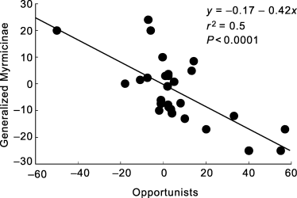

**Figure 2**

Open in figure viewer[PowerPoint](https://onlinelibrary.wiley.com/action/downloadFigures?id=f2&doi=10.1046%2Fj.1442-9993.2003.01301.x)

Relationship of the change in contribution of total ant abundance (%) of Opportunists and Generalized Myrmicinae as found in all studies of disturbance reviewed here where functional groups were analysed.

#### Specialist Predators

The Specialist Predators typically showed a weak response (Table 3), which was likely to be an artefact of low sampling efficiency because of the generally low abundance of its component species. The group tended to be a decreaser (nine out of 15 cases).

## Discussion

### Variable responses

Our analysis showed that ant species, species‐groups and functional groups all show a variable response to disturbance. Such variation is inevitable because of at least three confounding factors.

First, a species' response is likely to vary with habitat because of differential effects of disturbance on habitat suitability (Pickett & White 1985; Pimm 1991). In particular, disturbance is likely to have an adverse effect when a species occurs in its most preferred habitat, whereas disturbance might actually improve habitat suitability when a species occurs in a non‐preferred habitat. For example, species of *Melophorus* and other Hot Climate Specialists prefer open habitats, and in well‐forested (i.e. non‐preferred) habitats they are typically increasers in response to moderate disturbance such as fire (Majer 1978; Andersen 1991a; Vanderwoude *et al*. 1997). In contrast, they are decreasers in open habitats when disturbance results in an increase in plant cover through invasion by weeds or colonization by early successional species (Burbidge *et al*. 1992; Andersen 1993). The same disturbance can differentially affect environmental variables even within similar habitats. For example, grazing has different effects on vertical complexity, grass cover, litter cover and soil strength in different grasslands of western USA, and ant communities accordingly show different responses (Bestelmeyer & Wiens 2001).

Second, the responses of species are unlikely to be linear, as is the case of species' responses to environmental gradients in general (Austin 1987). For example, most increaser species are likely to show a bell‐shaped response, increasing under conditions of low to moderate disturbance, but decreasing as disturbance becomes more severe. The disturbances considered here varied enormously in their severity, and this clearly contributed to the variable responses that we have documented. In particular, disturbances such as mining and agriculture that have a direct impact on soil and therefore ant nests (i.e. strict disturbance from an ant's perspective, *sensu*Grime 1979), are qualitatively different from those, such as fire and grazing, that act primarily by removing plant biomass. It is therefore hardly surprising that mining caused a greater proportion of strong responses than did either fire or grazing (Table 4). The confounding influence of curvilinear responses is illustrated by patterns of ant colonization at minesites undergoing rehabilitation. Few species occurred at the very early stages of rehabilitation (i.e. most severe disturbance), such that virtually all species would be classified as decreasers on this basis. However, many species occurred at higher abundance at mid‐succession than they did at undisturbed sites (Majer *et al*. 1982; Jackson & Fox 1996; Majer & Nichols 1998; Bisevac & Majer 1999), and would therefore be classified as increasers on that basis.

Table 4. **.** Number of strong and very strong responses of functional groups of ants to disturbances

| Functional group | Grazing (7) | Fire (9) | Mining (8) | Other (6) |
| --- | --- | --- | --- | --- |
| Dominant Dolichoderinae | – | 4 | 8 | 5 |
| Subordinate Camponotini | 2 | 1 | 3 | 2 |
| Hot Climate Specialists | 1 | 3 | 3 | 2 |
| Cold Climate Specialists | – | 1 | 4 | 1 |
| Cryptic Species | 2 | 4 | 3 | 2 |
| Opportunists | 2 | 4 | 5 | 2 |
| Generalized Myrmicinae | 2 | 3 | 7 | 2 |
| Specialist Predators | – | – | – | 2 |
| Total | 9 | 20 | 33 | 18 |

- Number of studies of each disturbance is given in parentheses.

The third confounding factor is time since disturbance, because an immediate response (incorporating direct mortality) may differ from one in the longer term (reflecting habitat suitability). Many studies, for example, have shown that the abundance of Dominant Dolichoderinae, such as species of *Iridomyrmex* and *Anonychomyrma*, increases in the longer term in response to fire (O'Dowd & Gill 1984; Andersen 1988, 1991a; Neumann 1991, 1992; Vanderwoude *et al*. 1997), because of increased insolation in the ground‐layer. However, fire resulted in an immediate reduction in the abundance of *Iridomyrmex* in one study (Andersen & Yen 1985), and the authors postulated that species of *Iridomyrmex* might have an unusually high proportion of workers foraging at any given time, and therefore be disproportionately affected by direct mortality during fire.

### Species and species‐group responses

Arguably the most useful bioindicators for particular studies are widespread species that show well‐known and predictable response to disturbance. However, for the reasons outlined herein, such species will not always show a consistent response in the sort of analysis we have presented here; responses will always need to be interpreted in the context of habitat type, severity of disturbance and time. With this caveat, widespread species and species‐groups can be identified as target indicators in each of the major biogeographical zones in Australia. The most striking examples are species of the *metallica* group of *Rhytidoponera* in temperate southern Australia, which were consistently increasers. The most notable of these were *R. tasmaniensis* and *R. metallica* in the south‐east (Yeatman & Greenslade 1980; Andersen & McKaige 1987; Lobry de Bruyn 1993; Neville *et al*. 1997; York 2000), and *R. inornata* in the south‐west (Majer 1980; Majer & Brown 1986). *Anonychomyrma biconvexa* also appeared to be a consistent increaser in temperate south‐eastern Australia (O'Dowd & Gill 1984; Andersen 1988; Neumann 1991, 1992), whereas *Aphaenogaster longiceps* appeared to be a consistent decreaser (Andersen 1988; Lobry de Bruyn 1993; Jackson & Fox 1996; Vanderwoude *et al*. 1997).

Species of the *terebrans* group of *Camponotus* appeared to be consistent increasers throughout the southern semiarid zone. We are only aware of one published study that documents such a response (Bisevac & Majer 1999), but our unpublished observations indicate that such species commonly have inflated abundances in disturbed areas, such as around homesteads. Species of the closely related *denticulatus* group of *Camponotus*, which occur throughout the central and northern arid zones, also appear to be consistent increasers (Andersen & Hoffmann 1999; Hoffmann 2000; Hoffmann *et al*. 2000; Andersen *et al*. 2002). *Camponotus denticulatus* itself is the major representative of the group throughout the central arid zone, and is one of the most conspicuous ants in suburban Alice Springs.

Species of the *aeneovirens* group of *Melophorus* also appeared to be relatively consistent increasers in the northern arid zone (Andersen 1991a; Vanderwoude *et al*. 1997; Andersen & Hoffmann 1999; Hoffmann 2000). *Iridomyrmex pallidus* is one of the most common ants throughout monsoonal Australia, and appeared to be a consistent increaser (Andersen 1991a; Andersen & Hoffmann 1999; Hoffmann *et al*. 2000). However, in a very recent study not included in this analysis, this species apparently decreased in abundance in relation to grazing in North Queensland (Woinarski *et al*. 2002). Finally, *Brachyponera lutea* occurs throughout most of mainland Australia outside the central arid zone, and has been widely reported as an increaser (Majer 1984; Jackson & Fox 1996; Vanderwoude *et al*. 1997; Andersen & Hoffmann 1999; York 2000).

### Functional group response

There are several reasons why the responses of functional groups to disturbance would be expected to be more variable than those of individual species. The first and most obvious is generic to any functional group scheme: a single species is a much ‘tighter’ biological entity than is a combination of species. Second, the functional groups used here are based on a range of ecological factors rather than specifically on disturbance (i.e. they are not disturbance‐response groups; Lavorel *et al*. 1997). Indeed, stress factors relating to temperature, habitat structure and competitive interactions play the dominant role in shaping the functional group scheme, with disturbance acting indirectly through its effects on these (Andersen 2000b). For example, Cryptic Species are classified because of a specialist lifestyle in soil and litter, which comes with a suite of morphological characters such as small body size, reduced eye‐size, and tubular body. They are often sensitive to disturbance because of the effects of disturbance on the litter‐layer, but this is not the basis of their classification. Similarly, Opportunists are typically ruderal species (*sensu*Grime 1979) that often proliferate at disturbed sites. However, this only occurs when disturbance puts them at a competitive advantage over other ants. When disturbance favours other taxa, such as the case of fire promoting Dominant Dolichoderinae in forests (Neville *et al*. 1997; Vanderwoude *et al*. 1997), then the abundance of Opportunists is actually reduced.

Third, the functional group scheme classifies ants at higher taxonomic levels (genera and species‐groups, rather than species) according to that taxon's broad behaviour at biogeographical scales. It does not aim to account for the behaviour of individual species at particular sites. As an analogy, ‘grass’ represents a monophyletic plant life‐form that plays a key role in analyses of vegetation dynamics. From a global perspective it is a dominant functional group under conditions of moderate to high levels of disturbance (Grime 1979), but this generalization hardly means that all grass species are always increasers.

Fourth, some taxa are not known well enough to be able to classify them with confidence, or simply do not fit neatly into any particular group. For example, *Adlerzia* has been placed by different authors into different groups, including Hot Climate Specialists (Andersen 1995; Vanderwoude *et al*. 1997; Bisevac & Majer 1999) and Cryptic species (Majer & Brown 1986; Andersen *et al*. 2003). It is considered here to belong to the Cryptic Species because of its small body size, reduced eyes, and membership within the predominantly cryptic tribe Pheidologetonini. However, unlike most other Cryptic Species, *Adlerzia* occurs primarily in open woodland rather than wetter forest (Shattuck 1999), is common in urban areas (Majer & Brown 1986) and is promoted by fire (Andersen & Yen 1985; Vanderwoude *et al*. 1997).

The responses of functional groups to disturbance are therefore necessarily context‐specific, and species within a functional group are likely to show a range of responses. Given these qualifications, the following can be identified as recurring patterns of functional group responses to disturbance in Australia:

- 1

  In well‐forested areas, low to moderate disturbance such as fire and grazing favours Dominant Dolichoderinae and Hot Climate Specialists, because of habitat simplification and increased insolation of the ground‐layer (Andersen 1991a; Neville *et al*. 1997; Vanderwoude *et al*. 1997; King *et al*. 1998; Woinarski *et al*. 2002). This often leads to a reduction in Opportunists (Andersen 1993; Neville *et al*. 1997; Vanderwoude *et al*. 1997).
- 2

  Conversely, the abundances of Dominant Dolichoderinae and Hot Climate Specialists are reduced when disturbance involves the formation of dense shaded areas with a thick layer of litter, and this leads to an increase in abundance of Opportunists (Burbidge *et al*. 1992; Andersen 1993; Abensberg‐Traun *et al*. 1996).
- 3

  Throughout higher rainfall regions of eastern and southern Australia, severe disturbance (involving extensive vegetation clearing) typically leads to a proliferation of Opportunists, especially small species of *Rhytidoponera* (Majer *et al*. 1982; Yeatman & Greenslade 1980; Andersen & McKaige 1987; King *et al*. 1998). This also occurred under a frequent fire regime in blackbutt forests of New South Wales (York 2000), but not in spotted gum forests of south‐eastern Queensland (Vanderwoude *et al*. 1997).
- 4

  Cryptic Species are consistently decreasers in relation to disturbance (Majer *et al*. 1982; Andersen & McKaige 1987; Andersen 1991a; King *et al*. 1998; York 2000), presumably because of negative impacts on the litter‐layer.
- 5

  In any particular case, Generalized Myrmicinae and Opportunists tend to show opposite responses to disturbance. The reasons for this relationship are not well‐understood. Both groups consist of broadly adapted taxa, but are known to have different habitat preferences and competitive abilities (Andersen 1995, 2000b).
- 6

### Conclusion

We have identified a number of widespread ant species and species‐groups that appear to show a predictable response to disturbance, and they cover a wide range of environments. However, there are relatively few of them, and collectively they will be absent from many local ant faunas. This makes the broadscale predictive capacity of functional groups in the absence of detailed species‐level information an attractive proposition. Functional group analysis also has the advantage of providing a ‘whole of community’ response, rather than relying on what might be an idiosyncratic response of a single species, and does so from an explicitly ecological perspective.

The functional group scheme was designed to enable ant community organization to be compared across biogeographical zones, and is most useful in a disturbance context when the effect of disturbance on habitat structure is analogous to biogeographical‐scale change in habitat structure. In such cases disturbance causes vegetation structure to change beyond the range to which local species are typically adapted (Bestelmeyer & Wiens 2001). The scheme can be particularly useful in a minesite rehabilitation context, which involves major successional changes in vegetation structure, and this is reflected in comparable changes in functional group composition (Andersen 1993; Bisevac & Majer 1999). It is also useful in well‐forested habitats, where even relatively low levels of disturbance such as fire can have a marked impact on habitat structure, particularly at ground level.

The functional group scheme appears to be least useful as a basis for analysing ant community dynamics within the arid zone. This is because most xeric vegetation types are already very open, so that low levels of disturbance have relatively little impact on gross habitat structure (e.g. increasing what is already extensive bare ground; Bestelmeyer & Wiens 2001), and therefore on functional group composition. This possibly accounts for the relatively few responses of functional groups to grazing (Table 3), as most such studies have been conducted in arid and semiarid rangelands. Indeed, ant communities in such rangeland habitats of North America are also known to be particularly resilient (Whitford *et al*. 1999; Bestelmeyer & Wiens 2001). But in a recent study in arid New South Wales rangelands, analyses of ant abundance data at the functional group level discriminated habitat type and land condition better than analysis at the species level (A. Andersen, unpubl. data).

In conclusion, the functional group scheme can provide a useful predictive framework for assessing ant community responses to disturbance when such disturbance causes marked change in vegetation structure. This means that it can play an important role in assessing ecological disturbance in mesic Australia, but may be of more limited use for this in the arid zone.

## Acknowledgements

We thank Allan Burbidge, Jonathan Majer, Peter Neville, John Read and Cas Vanderwoude for graciously providing us with their data, and Brandon Bestelmeyer, Dieter Hochuli, Jonathan Majer and Alan York for their valuable comments on the manuscript. An Australian Postgraduate Award and a Scholarship from the Tropical Savannas CRC to Ben Hoffmann supported the writing of this paper. This work contributed to Ben Hoffmann's PhD thesis with the Northern Territory University. This is TERC publication number 1217.

## Citing Literature

[Volume28, Issue4](https://onlinelibrary.wiley.com/toc/14429993/2003/28/4)

August 2003

Pages 444-464

### Metrics

- Citations: 178

### Keywords

  - bioindicators
  - [environmental assessment](https://onlinelibrary.wiley.com/action/doSearch?field1=Keyword&text1=environmental%20assessment)
  - fire
  - grazing
  - [land management](https://onlinelibrary.wiley.com/action/doSearch?field1=Keyword&text1=land%20management)
  - [minesite rehabilitation](https://onlinelibrary.wiley.com/action/doSearch?field1=Keyword&text1=minesite%20rehabilitation)

### Publication History

  - Issue Online: 25 July 2003
  - Version of Record online: 25 July 2003
  - Editorial history: Accepted for publication February 2003.

[Download PDF](https://onlinelibrary.wiley.com/doi/pdf/10.1046/j.1442-9993.2003.01301.x)

back